# PARKINSON DATASET

JOSÉ LUIS

2024-10-08

# CÓDIGO

Este documento contiene un preprocesamiento de datos inicial que permite un buen estudio exploratorio EDA. Luego, contiene un preprocesamiento más avanzado que permite la creación de varios modelos que expliquen bien la variable objetivo (status) para poder evaluarlo a través de validación cruzada.

## LIBRERIAS

```r
# All these libraries may not be used in the chunks. It's just a standar libraries i always use just to not have to search for them in case i need them.
library(caret)
library(ConfusionTableR)
library(DataExplorer)
library(dplyr)
library(ggplot2)
library(ggthemes)
library(kableExtra)
library(ModelMetrics)
library(openxlsx)
library(plotly)
library(probably)
library(pROC)
library(psych)
library(purrr)
library(randomForest)
library(reshape2)
library(skimr)
library(stringr)
library(tidymodels)
library(tidyverse)
library(univariateML)
library(vip)
library(xgboost)
library(WRS2)
library(GGally)
library(lmtest)
library(e1071)
library(fastDummies)
library(class)
library(ROCR)
library(corrplot)
```

## PREPROCESAMIENTO INICIAL

OBSERVAMOS NUESTRO DATASET SIN NINGUNA MODIFICACIÓN

### DATASET Y VARIABLES

```r
# Primero observamos un poco el dataset
data = read.csv("parkinsons.csv")
head(data) %>% kable(format = "html") %>%
  kable_styling(bootstrap_options = c("striped", "hover", "condensed"),
                full_width = FALSE, position = "center", font_size = 12) %>%
  row_spec(0, background = "#287289", color = "white")
```

| name | MDVP.Fo.Hz. | MDVP.Fhi.Hz. | MDVP.Flo.Hz. | MDVP.Jitter… | MDVP.Jitter.Abs. | MDVP.RAP | MDVP.PPQ | Jitter.DDP | MDVP.Shimmer | MDVP.Shimmer.dB. | Shimmer.APQ3 | Shimmer.APQ5 | MDVP.APQ | Shimmer.DDA | NHR | HNR | status | RPDE | DFA | spread1 | spread2 | D2 | PPE |
| --- | --- | --- | --- | --- | --- | --- | --- | --- | --- | --- | --- | --- | --- | --- | --- | --- | --- | --- | --- | --- | --- | --- | --- |
| phon_R01_S01_1 | 119.992 | 157.302 | 74.997 | 0.00784 | 0.00007 | 0.00370 | 0.00554 | 0.01109 | 0.04374 | 0.426 | 0.02182 | 0.03130 | 0.02971 | 0.06545 | 0.02211 | 21.033 | 1 | 0.414783 | 0.815285 | -4.813031 | 0.266482 | 2.301442 | 0.284654 |
| phon_R01_S01_2 | 122.400 | 148.650 | 113.819 | 0.00968 | 0.00008 | 0.00465 | 0.00696 | 0.01394 | 0.06134 | 0.626 | 0.03134 | 0.04518 | 0.04368 | 0.09403 | 0.01929 | 19.085 | 1 | 0.458359 | 0.819521 | -4.075192 | 0.335590 | 2.486855 | 0.368674 |
| phon_R01_S01_3 | 116.682 | 131.111 | 111.555 | 0.01050 | 0.00009 | 0.00544 | 0.00781 | 0.01633 | 0.05233 | 0.482 | 0.02757 | 0.03858 | 0.03590 | 0.08270 | 0.01309 | 20.651 | 1 | 0.429895 | 0.825288 | -4.443179 | 0.311173 | 2.342259 | 0.332634 |
| phon_R01_S01_4 | 116.676 | 137.871 | 111.366 | 0.00997 | 0.00009 | 0.00502 | 0.00698 | 0.01505 | 0.05492 | 0.517 | 0.02924 | 0.04005 | 0.03772 | 0.08771 | 0.01353 | 20.644 | 1 | 0.434969 | 0.819235 | -4.117501 | 0.334147 | 2.405554 | 0.368975 |
| phon_R01_S01_5 | 116.014 | 141.781 | 110.655 | 0.01284 | 0.00011 | 0.00655 | 0.00908 | 0.01966 | 0.06425 | 0.584 | 0.03490 | 0.04825 | 0.04465 | 0.10470 | 0.01767 | 19.649 | 1 | 0.417356 | 0.823484 | -3.747787 | 0.234513 | 2.332180 | 0.410335 |
| phon_R01_S01_6 | 120.552 | 131.162 | 113.787 | 0.00968 | 0.00008 | 0.00463 | 0.00750 | 0.01388 | 0.04701 | 0.456 | 0.02328 | 0.03526 | 0.03243 | 0.06985 | 0.01222 | 21.378 | 1 | 0.415564 | 0.825069 | -4.242867 | 0.299111 | 2.187560 | 0.357775 |

VAMOS A VER EL NOMBRE DE LAS VARIABLES Y UNA PEQUEÑA DESCRIPCIÓN JUNTO CON EL TIPO DE DATO QUE ES.

```r
colnames(data)
```

```
 [1] "name"             "MDVP.Fo.Hz."      "MDVP.Fhi.Hz."     "MDVP.Flo.Hz."
 [5] "MDVP.Jitter..."   "MDVP.Jitter.Abs." "MDVP.RAP"         "MDVP.PPQ"
 [9] "Jitter.DDP"       "MDVP.Shimmer"     "MDVP.Shimmer.dB." "Shimmer.APQ3"
[13] "Shimmer.APQ5"     "MDVP.APQ"         "Shimmer.DDA"      "NHR"
[17] "HNR"              "status"           "RPDE"             "DFA"
[21] "spread1"          "spread2"          "D2"               "PPE"
```

VARIABLES y tipo:

-**MDVP.Fo.Hz:** Average vocal fundamental frequency / numerica continua

-**MDVP.Fhi.Hz.:** Maximum vocal fundamental frequency / numerica continua

-**MDVP.Flo.Hz:** Minimum vocal fundamental frequency / numerica continua

-**MDVP.Jitter.:** Several measures of variation in fundamental frequency / numerica continua

-**MDVP.Jitter.Abs.:** Several measures of variation in fundamental frequency / numerica continua

-**MDVP.RAP:** Several measures of variation in fundamental frequency / numerica continua

-**MDVP.PPQ:** Several measures of variation in fundamental frequency / numerica continua

-**Jitter.DDP:** Several measures of variation in fundamental frequency / numerica continua

-**MDVP.Shimmer:** Several measures of variation in amplitude / numerica continua

-**MDVP.Shimmer.dB.:** Several measures of variation in amplitude / numerica continua

-**Shimmer.APQ3:** Several measures of variation in amplitude / numerica continua

-**Shimmer.APQ5:** Several measures of variation in amplitude / numerica continua

-**MDVP.APQ:** Several measures of variation in amplitude / numerica continua

-**Shimmer.DDA:** Several measures of variation in amplitude / numerica continua

-**NHR:** measure of ratio of noise to tonal components in the voice / numerica continua

-**HNR:** measure of ratio of noise to tonal components in the voice / numerica continua

-**RPDE:** nonlinear dynamical complexity measure / numerica continua

-**DFA:** Signal fractal scaling exponent / numerica continua

-**spread1:** nonlinear measure of fundamental frequency variation / numerica continua

-**spread2:** nonlinear measure of fundamental frequency variation / numerica continua

-**D2:** nonlinear dynamical complexity measure / numerica continua

-**PPE:** nonlinear measure of fundamental frequency variation / numerica continua

### PREPROCESAMIENTO INICIAL

PRIMERO VAMOS A CAMBIAR EL NOMBRE DE LA COLUMNA “MDVP.JITTER…” PARA QUE TODAS ESTÉN CON EL MISMO FORMATO.

```r
data <- rename(data, MDVP.Jitter. = MDVP.Jitter...) # tiene 3 puntos cuando otras solo tiene 1. Lo dejamos con un solo punto y asi no tenemos qu cambiar el resto para dejarlas con el mismo formato.
```

ELIMINAMOS LA COLUMNA NAME, PUES NO NOS HARÁ FALTA PARA LOS ANÁLISIS POSTERIORES

```r
data["name"] = NULL
```

VEAMOS LA ESTRUCTURA DE NUESTRO DATASET

```r
str(data)
```

```
'data.frame':   195 obs. of  23 variables:
 $ MDVP.Fo.Hz.     : num  120 122 117 117 116 ...
 $ MDVP.Fhi.Hz.    : num  157 149 131 138 142 ...
 $ MDVP.Flo.Hz.    : num  75 114 112 111 111 ...
 $ MDVP.Jitter.    : num  0.00784 0.00968 0.0105 0.00997 0.01284 ...
 $ MDVP.Jitter.Abs.: num  0.00007 0.00008 0.00009 0.00009 0.00011 0.00008 0.00003 0.00003 0.00006 0.00006 ...
 $ MDVP.RAP        : num  0.0037 0.00465 0.00544 0.00502 0.00655 0.00463 0.00155 0.00144 0.00293 0.00268 ...
 $ MDVP.PPQ        : num  0.00554 0.00696 0.00781 0.00698 0.00908 0.0075 0.00202 0.00182 0.00332 0.00332 ...
 $ Jitter.DDP      : num  0.0111 0.0139 0.0163 0.015 0.0197 ...
 $ MDVP.Shimmer    : num  0.0437 0.0613 0.0523 0.0549 0.0643 ...
 $ MDVP.Shimmer.dB.: num  0.426 0.626 0.482 0.517 0.584 0.456 0.14 0.134 0.191 0.255 ...
 $ Shimmer.APQ3    : num  0.0218 0.0313 0.0276 0.0292 0.0349 ...
 $ Shimmer.APQ5    : num  0.0313 0.0452 0.0386 0.0401 0.0483 ...
 $ MDVP.APQ        : num  0.0297 0.0437 0.0359 0.0377 0.0447 ...
 $ Shimmer.DDA     : num  0.0654 0.094 0.0827 0.0877 0.1047 ...
 $ NHR             : num  0.0221 0.0193 0.0131 0.0135 0.0177 ...
 $ HNR             : num  21 19.1 20.7 20.6 19.6 ...
 $ status          : int  1 1 1 1 1 1 1 1 1 1 ...
 $ RPDE            : num  0.415 0.458 0.43 0.435 0.417 ...
 $ DFA             : num  0.815 0.82 0.825 0.819 0.823 ...
 $ spread1         : num  -4.81 -4.08 -4.44 -4.12 -3.75 ...
 $ spread2         : num  0.266 0.336 0.311 0.334 0.235 ...
 $ D2              : num  2.3 2.49 2.34 2.41 2.33 ...
 $ PPE             : num  0.285 0.369 0.333 0.369 0.41 ...
```

AQUI PODEMOS OBSERVAR LAS VARIABLES QUE SON NUMERICAS Y LAS QUE DEBERIAN DE SER CATEGORICAS (COMO status)

status ES NUESTRA VARIABLE TARGET Y ES UNA VARIABLE CATEGORICA BINARIA. LA TRANSFORMAMOS A FACTOR

```r
data$status = as.factor(data$status)
```

ES MUY IMPORTANTE VER SI NUESTRO DATASET TIENE MISSING VALUES, CUANTOS Y EN QUE COLUMNAS. SI HAY 0, SIN NINGÚN PROBLEMA. SI POR EL CONTRARIO, TENEMOS, DEBEMOS VER QUE HACER CON ELLOS (ELIMINARLOS, IMPUTARLOS, ETC)

```r
missing_values = colSums(is.na(data))

missing_values
```

```
     MDVP.Fo.Hz.     MDVP.Fhi.Hz.     MDVP.Flo.Hz.     MDVP.Jitter.
               0                0                0                0
MDVP.Jitter.Abs.         MDVP.RAP         MDVP.PPQ       Jitter.DDP
               0                0                0                0
    MDVP.Shimmer MDVP.Shimmer.dB.     Shimmer.APQ3     Shimmer.APQ5
               0                0                0                0
        MDVP.APQ      Shimmer.DDA              NHR              HNR
               0                0                0                0
          status             RPDE              DFA          spread1
               0                0                0                0
         spread2               D2              PPE
               0                0                0
```

OBSERVAMOS QUE NO HAY NINGÚN MISSING VALUE, LO CUAL NOS QUITA CIERTO PESO EN CUANTO ELIMINACIÓN, IMPUTACIÓN, ETC.

## ANÁLISIS DESCRIPTIVO

UNA FORMA MUY SENCILLA DE VER UN POCO LA MEDIA, DESVIACIÓN ESTANDAR, MINIMOS, MAXIMOS (EN EL CASO DE VARIABLES NUMERICAS) Y EL RECUENTO DE NIVELES (PARA VARIABLES CATEGORICAS) ES A TRAVÉS DEL SUMMARY

```r
summary(data)
```

```
  MDVP.Fo.Hz.      MDVP.Fhi.Hz.    MDVP.Flo.Hz.     MDVP.Jitter.
 Min.   : 88.33   Min.   :102.1   Min.   : 65.48   Min.   :0.001680
 1st Qu.:117.57   1st Qu.:134.9   1st Qu.: 84.29   1st Qu.:0.003460
 Median :148.79   Median :175.8   Median :104.31   Median :0.004940
 Mean   :154.23   Mean   :197.1   Mean   :116.32   Mean   :0.006220
 3rd Qu.:182.77   3rd Qu.:224.2   3rd Qu.:140.02   3rd Qu.:0.007365
 Max.   :260.11   Max.   :592.0   Max.   :239.17   Max.   :0.033160
 MDVP.Jitter.Abs.       MDVP.RAP           MDVP.PPQ          Jitter.DDP
 Min.   :7.000e-06   Min.   :0.000680   Min.   :0.000920   Min.   :0.002040
 1st Qu.:2.000e-05   1st Qu.:0.001660   1st Qu.:0.001860   1st Qu.:0.004985
 Median :3.000e-05   Median :0.002500   Median :0.002690   Median :0.007490
 Mean   :4.396e-05   Mean   :0.003306   Mean   :0.003446   Mean   :0.009920
 3rd Qu.:6.000e-05   3rd Qu.:0.003835   3rd Qu.:0.003955   3rd Qu.:0.011505
 Max.   :2.600e-04   Max.   :0.021440   Max.   :0.019580   Max.   :0.064330
  MDVP.Shimmer     MDVP.Shimmer.dB.  Shimmer.APQ3       Shimmer.APQ5
 Min.   :0.00954   Min.   :0.0850   Min.   :0.004550   Min.   :0.00570
 1st Qu.:0.01650   1st Qu.:0.1485   1st Qu.:0.008245   1st Qu.:0.00958
 Median :0.02297   Median :0.2210   Median :0.012790   Median :0.01347
 Mean   :0.02971   Mean   :0.2823   Mean   :0.015664   Mean   :0.01788
 3rd Qu.:0.03789   3rd Qu.:0.3500   3rd Qu.:0.020265   3rd Qu.:0.02238
 Max.   :0.11908   Max.   :1.3020   Max.   :0.056470   Max.   :0.07940
    MDVP.APQ        Shimmer.DDA           NHR                HNR
 Min.   :0.00719   Min.   :0.01364   Min.   :0.000650   Min.   : 8.441
 1st Qu.:0.01308   1st Qu.:0.02474   1st Qu.:0.005925   1st Qu.:19.198
 Median :0.01826   Median :0.03836   Median :0.011660   Median :22.085
 Mean   :0.02408   Mean   :0.04699   Mean   :0.024847   Mean   :21.886
 3rd Qu.:0.02940   3rd Qu.:0.06080   3rd Qu.:0.025640   3rd Qu.:25.076
 Max.   :0.13778   Max.   :0.16942   Max.   :0.314820   Max.   :33.047
 status       RPDE             DFA            spread1          spread2
 0: 48   Min.   :0.2566   Min.   :0.5743   Min.   :-7.965   Min.   :0.006274
 1:147   1st Qu.:0.4213   1st Qu.:0.6748   1st Qu.:-6.450   1st Qu.:0.174350
         Median :0.4960   Median :0.7223   Median :-5.721   Median :0.218885
         Mean   :0.4985   Mean   :0.7181   Mean   :-5.684   Mean   :0.226510
         3rd Qu.:0.5876   3rd Qu.:0.7619   3rd Qu.:-5.046   3rd Qu.:0.279234
         Max.   :0.6852   Max.   :0.8253   Max.   :-2.434   Max.   :0.450493
       D2             PPE
 Min.   :1.423   Min.   :0.04454
 1st Qu.:2.099   1st Qu.:0.13745
 Median :2.362   Median :0.19405
 Mean   :2.382   Mean   :0.20655
 3rd Qu.:2.636   3rd Qu.:0.25298
 Max.   :3.671   Max.   :0.52737
```

EN ESTE SUMMARY, PODEMOS SACAR CIERTOS DATOS INTERESANTES. POR UN LADO, LAS VARIABLES COMO **MDVP.Fo.Hz.** y **MDVP.Fhi.Hz.** TIENEN VALORES MÍNIMOS BAJOS Y MÁXIMOS ELEVADOS, LO QUE PUEDE REFLEJAR VARIABILIDAD EN LA VOZ DE LOS PACIENTES. VARIABLES COMO **MDVP.Jitter.** y **Shimmer** TIENEN UNA MAYOR DISPERSION, CON VALORES EXTREMOS INDICATIVOS DE VARIABILIDAD EN LA SEÑAL DE LA VOZ, LO QUE PODRÍA SER RELEVANTE PARA IDENTIFICAR PATRONES RELACIONADOS CON LA ENFERMEDAD. ADEMÁS, LA VARIABLE **status** INDICA LA CLASIFICACIÓN DE LOS PACIENTES (0 = Sanos; 1 = Pacientes).

NO OBSTANTE, HAY FORMAS MÁS BONITAS DE PODER VER ESTOS MISMOS DATOS. A CONTINUACIÓN, PRESENTO UNA ALTERNATIVA MÁS LLAMATIVA

SKIMR

```r
library(skimr)

skim(data)
```

Data summary

| Name | data |
| --- | --- |
| Number of rows | 195 |
| Number of columns | 23 |
| _______________________ |  |
| Column type frequency: |  |
| factor | 1 |
| numeric | 22 |
| ________________________ |  |
| Group variables | None |

**Variable type: factor**

| skim_variable | n_missing | complete_rate | ordered | n_unique | top_counts |
| --- | --- | --- | --- | --- | --- |
| status | 0 | 1 | FALSE | 2 | 1: 147, 0: 48 |

**Variable type: numeric**

| skim_variable | n_missing | complete_rate | mean | sd | p0 | p25 | p50 | p75 | p100 | hist |
| --- | --- | --- | --- | --- | --- | --- | --- | --- | --- | --- |
| MDVP.Fo.Hz. | 0 | 1 | 154.23 | 41.39 | 88.33 | 117.57 | 148.79 | 182.77 | 260.10 | ▇▆▅▃▂ |
| MDVP.Fhi.Hz. | 0 | 1 | 197.10 | 91.49 | 102.14 | 134.86 | 175.83 | 224.21 | 592.03 | ▇▅▁▁▁ |
| MDVP.Flo.Hz. | 0 | 1 | 116.32 | 43.52 | 65.48 | 84.29 | 104.32 | 140.02 | 239.17 | ▇▅▂▁▁ |
| MDVP.Jitter. | 0 | 1 | 0.01 | 0.00 | 0.00 | 0.00 | 0.00 | 0.01 | 0.03 | ▇▁▁▁▁ |
| MDVP.Jitter.Abs. | 0 | 1 | 0.00 | 0.00 | 0.00 | 0.00 | 0.00 | 0.00 | 0.00 | ▇▂▁▁▁ |
| MDVP.RAP | 0 | 1 | 0.00 | 0.00 | 0.00 | 0.00 | 0.00 | 0.00 | 0.02 | ▇▁▁▁▁ |
| MDVP.PPQ | 0 | 1 | 0.00 | 0.00 | 0.00 | 0.00 | 0.00 | 0.00 | 0.02 | ▇▁▁▁▁ |
| Jitter.DDP | 0 | 1 | 0.01 | 0.01 | 0.00 | 0.00 | 0.01 | 0.01 | 0.06 | ▇▁▁▁▁ |
| MDVP.Shimmer | 0 | 1 | 0.03 | 0.02 | 0.01 | 0.02 | 0.02 | 0.04 | 0.12 | ▇▃▁▁▁ |
| MDVP.Shimmer.dB. | 0 | 1 | 0.28 | 0.19 | 0.09 | 0.15 | 0.22 | 0.35 | 1.30 | ▇▂▁▁▁ |
| Shimmer.APQ3 | 0 | 1 | 0.02 | 0.01 | 0.00 | 0.01 | 0.01 | 0.02 | 0.06 | ▇▃▁▁▁ |
| Shimmer.APQ5 | 0 | 1 | 0.02 | 0.01 | 0.01 | 0.01 | 0.01 | 0.02 | 0.08 | ▇▂▁▁▁ |
| MDVP.APQ | 0 | 1 | 0.02 | 0.02 | 0.01 | 0.01 | 0.02 | 0.03 | 0.14 | ▇▂▁▁▁ |
| Shimmer.DDA | 0 | 1 | 0.05 | 0.03 | 0.01 | 0.02 | 0.04 | 0.06 | 0.17 | ▇▃▁▁▁ |
| NHR | 0 | 1 | 0.02 | 0.04 | 0.00 | 0.01 | 0.01 | 0.03 | 0.31 | ▇▁▁▁▁ |
| HNR | 0 | 1 | 21.89 | 4.43 | 8.44 | 19.20 | 22.09 | 25.08 | 33.05 | ▁▂▇▇▁ |
| RPDE | 0 | 1 | 0.50 | 0.10 | 0.26 | 0.42 | 0.50 | 0.59 | 0.69 | ▂▅▇▆▆ |
| DFA | 0 | 1 | 0.72 | 0.06 | 0.57 | 0.67 | 0.72 | 0.76 | 0.83 | ▁▆▇▇▅ |
| spread1 | 0 | 1 | -5.68 | 1.09 | -7.96 | -6.45 | -5.72 | -5.05 | -2.43 | ▃▇▇▃▁ |
| spread2 | 0 | 1 | 0.23 | 0.08 | 0.01 | 0.17 | 0.22 | 0.28 | 0.45 | ▁▅▇▃▁ |
| D2 | 0 | 1 | 2.38 | 0.38 | 1.42 | 2.10 | 2.36 | 2.64 | 3.67 | ▂▇▇▃▁ |
| PPE | 0 | 1 | 0.21 | 0.09 | 0.04 | 0.14 | 0.19 | 0.25 | 0.53 | ▅▇▃▂▁ |

SKIM NOS CREA POR UN LADO, UNA SECCIÓN QUE NOS MUESTRA CUÁNTAS VARIABLES SON NUMÉRICAS Y CUÁNTAS CATEGÓRICAS Y, POR OTRO, DOS TIBBLES, QUE SON COMO DATAFRAMES Y SE ORGANIZAN EN CATEGÓRICAS, DANDO LOS CONTEOS, Y EN NUMÉRICAS, DANDO MÁS INFORMACIÓN QUE UN SUMMARY Y MÁS ESTRUCTURADO.

## VISUALIZACIÓN DE DATOS

EN ESTA SECCIÓN, VAMOS A VISUALIZAR LOS DATOS DE DISTINTA FORMA PARA VER LAS DIFERENTES OPCIONES QUE TENEMOS.

### BOXPLOTS

LOS BOXPLOTS SON LOS GRÁFICOS POR EXCELENCIA, PUES NOS PERMITEN VER MUCHOS PARÁMETROS COMO EL RANGO INTERCUARTILICO (NO DE FORMA EXPLICITA), LOS MÍNIMOS Y MAXIMOS, LA MEDIA, MEDIANA Y, MUY IMPORTANTE, LOS OUTLIERS QUE PUDIERA VER.

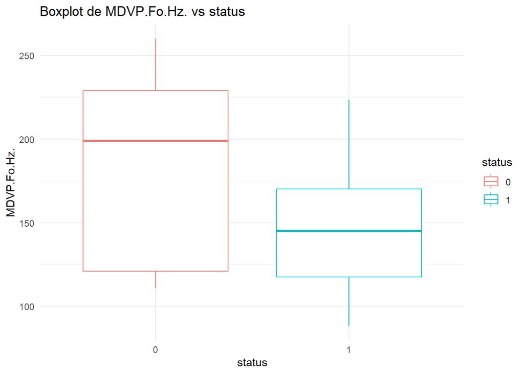

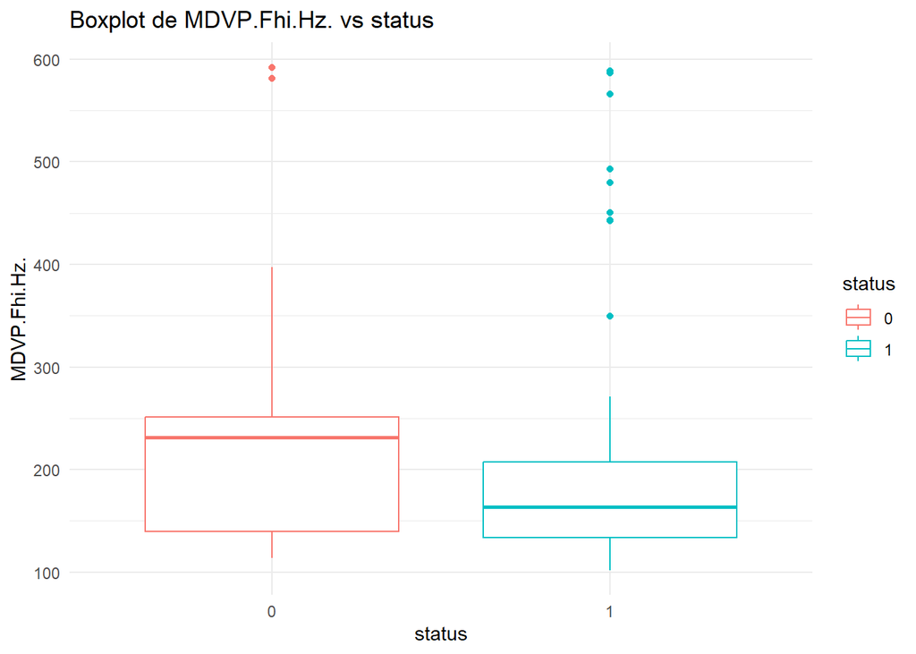

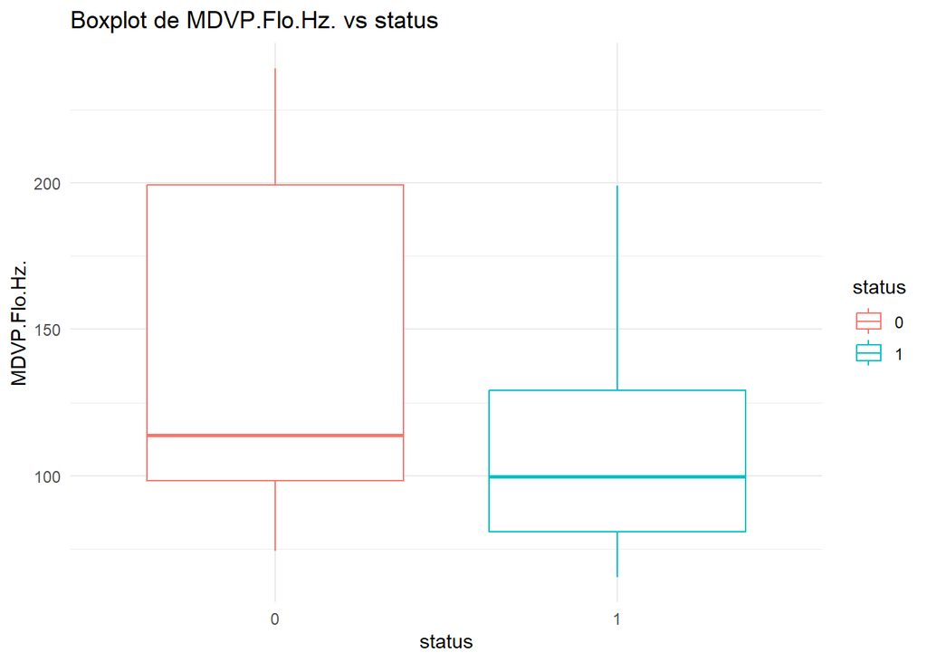

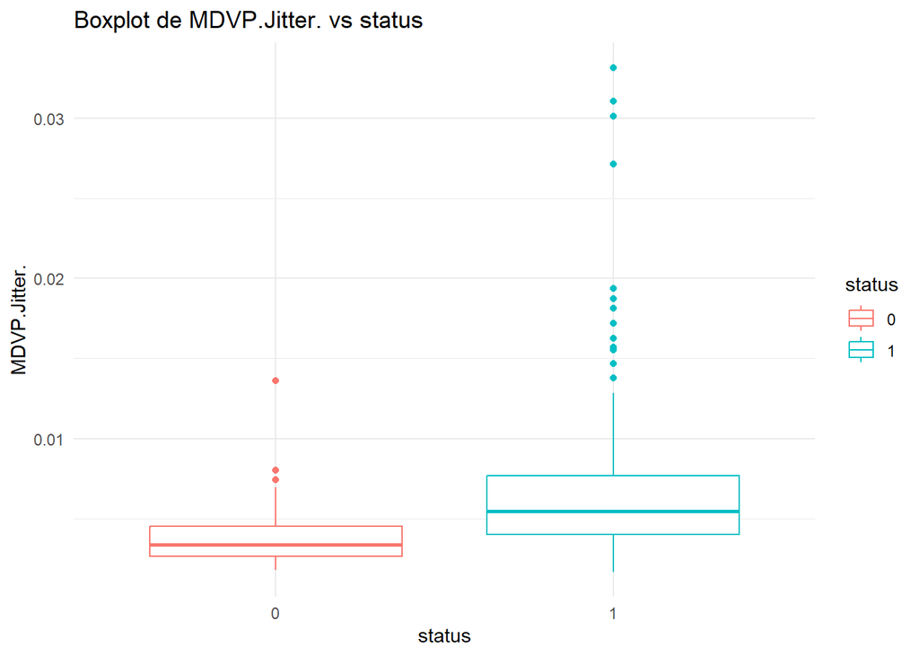

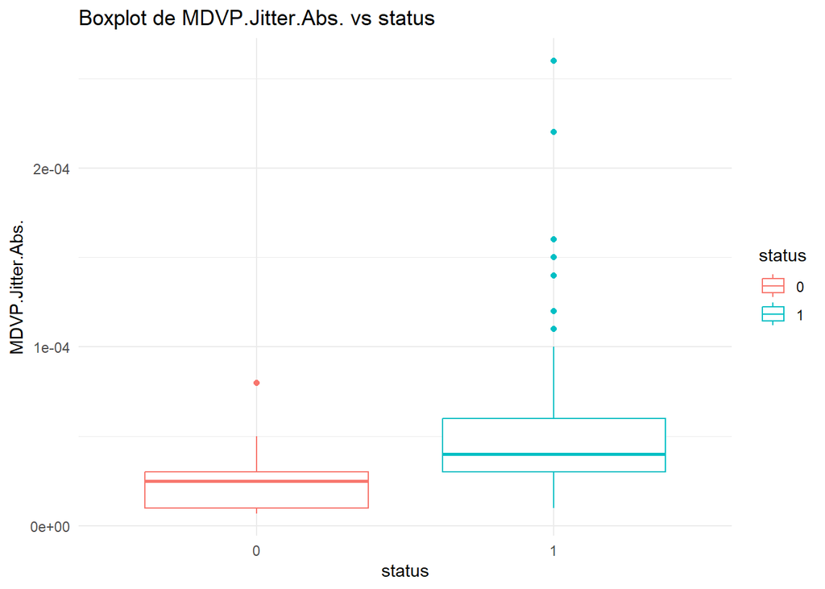

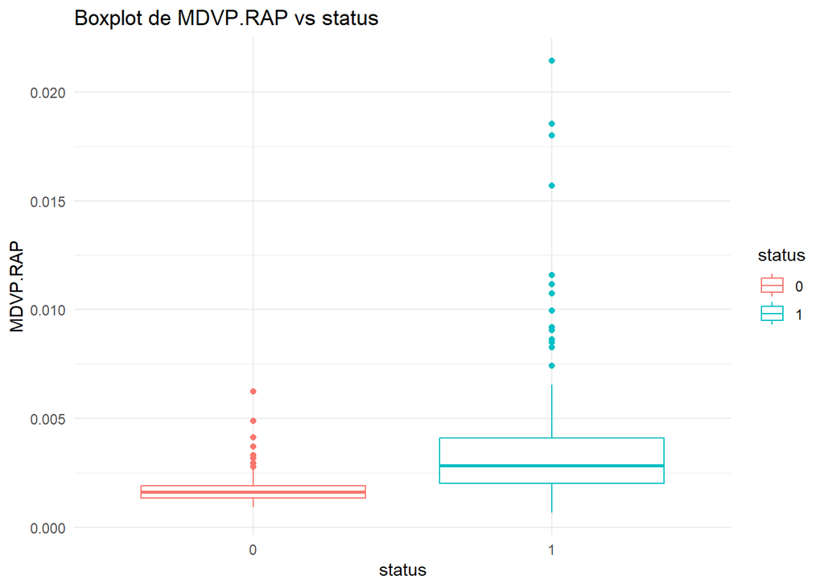

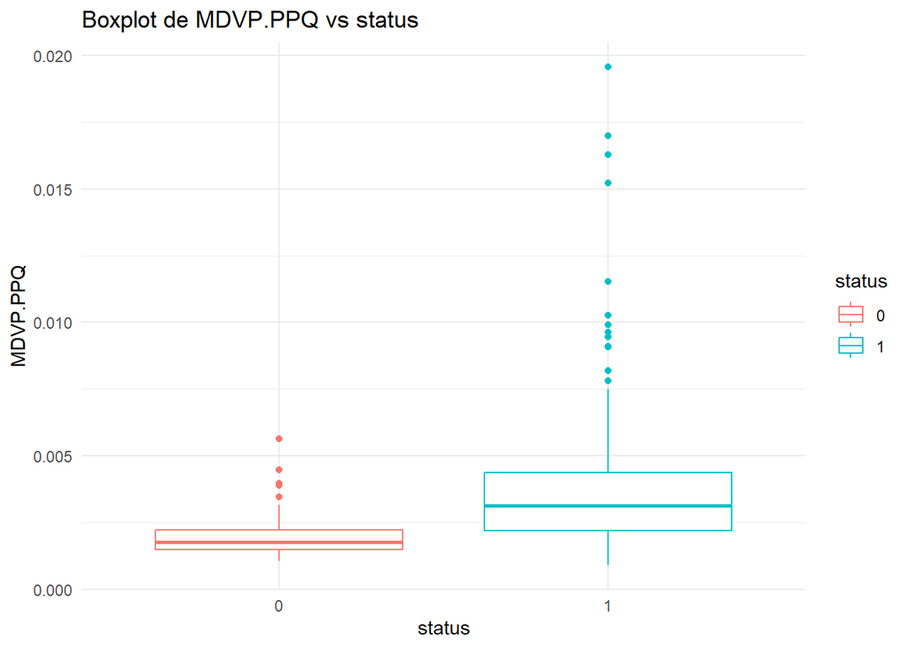

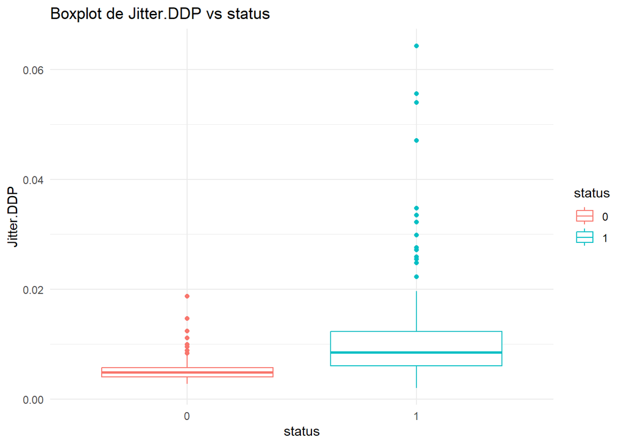

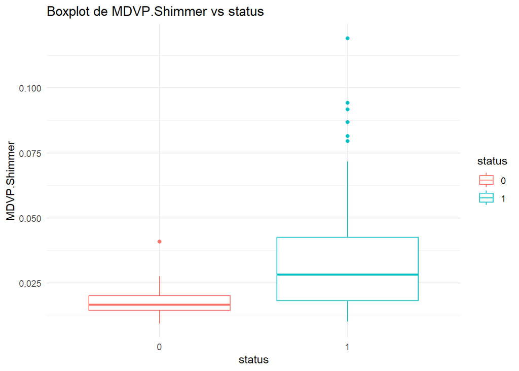

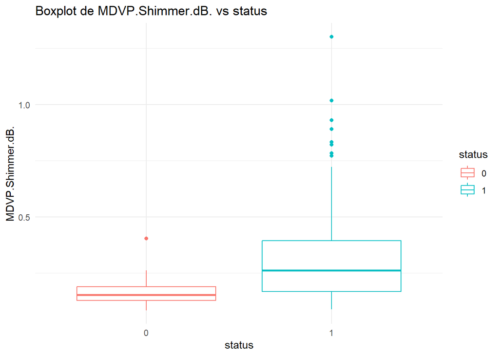

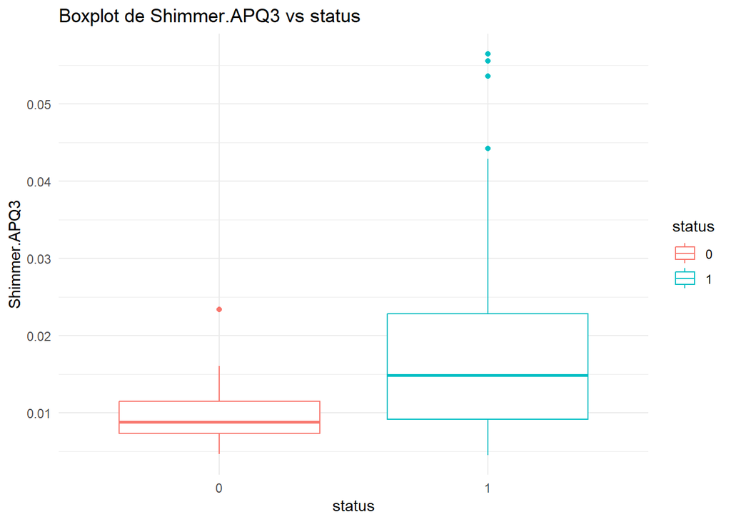

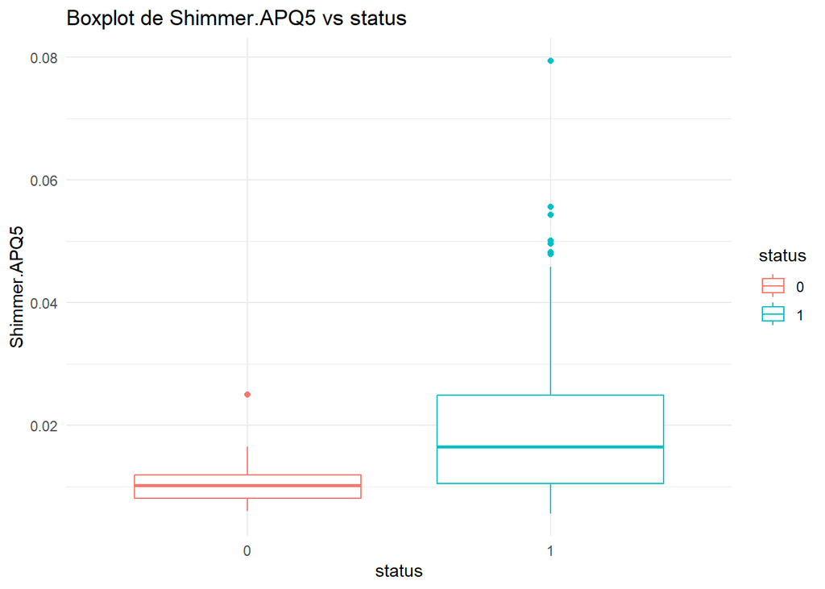

[10 more figures not shown]

```r
# Cogemos las variables numericas
variables_numericas = data %>%
  select(where(is.numeric))

# Hacemos un boxplot sencillo
for (var in colnames(variables_numericas)) {
  g = ggplot(data, aes(x = status, y = variables_numericas[[var]], col = status)) +
    geom_boxplot() +
    theme_minimal() +
    labs(x = "status", y = var) +
    ggtitle(paste("Boxplot de", var, "vs status"))

  print(g)

}
```

OBSERVAMOS DIFERENCIAS SIGNIFICATIVAS EN MDVP.fo.Hz DONDE PARECE HABER UNA MEDIA MÁS BAJA EN LA FRECUENCIA MEDIA EN PERSONAS QUE PADECEN PARKINSON CON RESPECTO A LOS QUE NO. ESTO MISMO OCURRE EN OTRAS MUCHAS VARIABLES. ADEMÁS, PODEMOS VER QUE VARIAS DE NUESTRAS VARIABLES PRESENTAN OUTLIERS. AQUI DEBEMOS REFLEXIONAR Y DECIDIR SI ESTOS OUTLIERS SON POR ERRORES DE MEDICIÓN U OTRO TIPO DE PROBLEMA EXTERNO O SI BIEN SON DATOS REALES AUNQUE SIMPLEMENTE ATÍPICOS. DEPENDIENDO DE LO QUE CONCLUYAMOS, PODEMOS ELIMINARLOS, DEJARLOS O LO QUE MEJOR VEAMOS. TAMBIEN ES INTERESANTE HACER MODELOS CON Y SIN OUTLIERS PARA VER SI EN LA EVALUACIÓN, MEJORAN EL RENDIMIENTO O NO.

### VIOLIN PLOT

EL VIOLIN PLOT ES MUY ÚTIL SI QUEREMOS VER COMO SE DISTRIBUYE LA DENSIDAD DE NUESTROS DATOS.

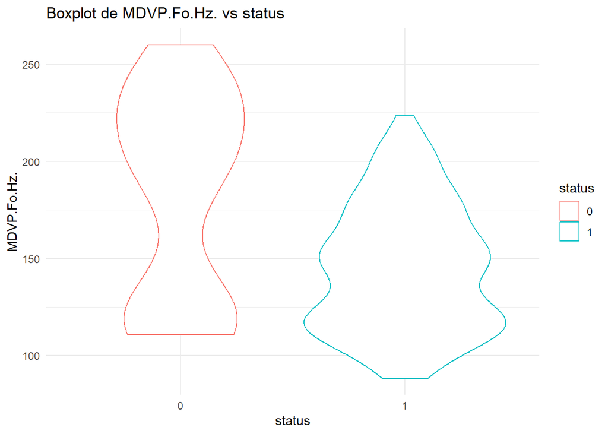

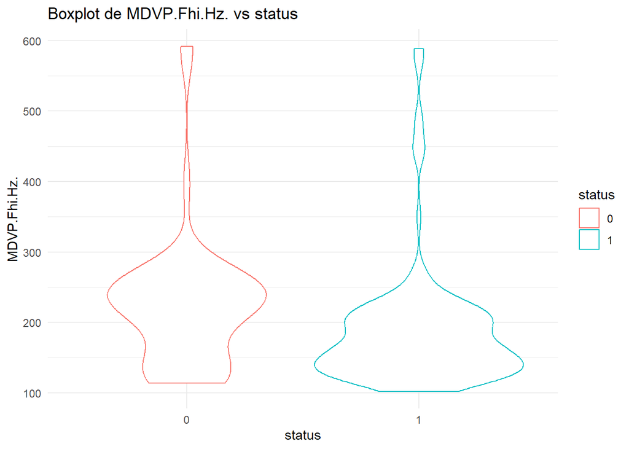

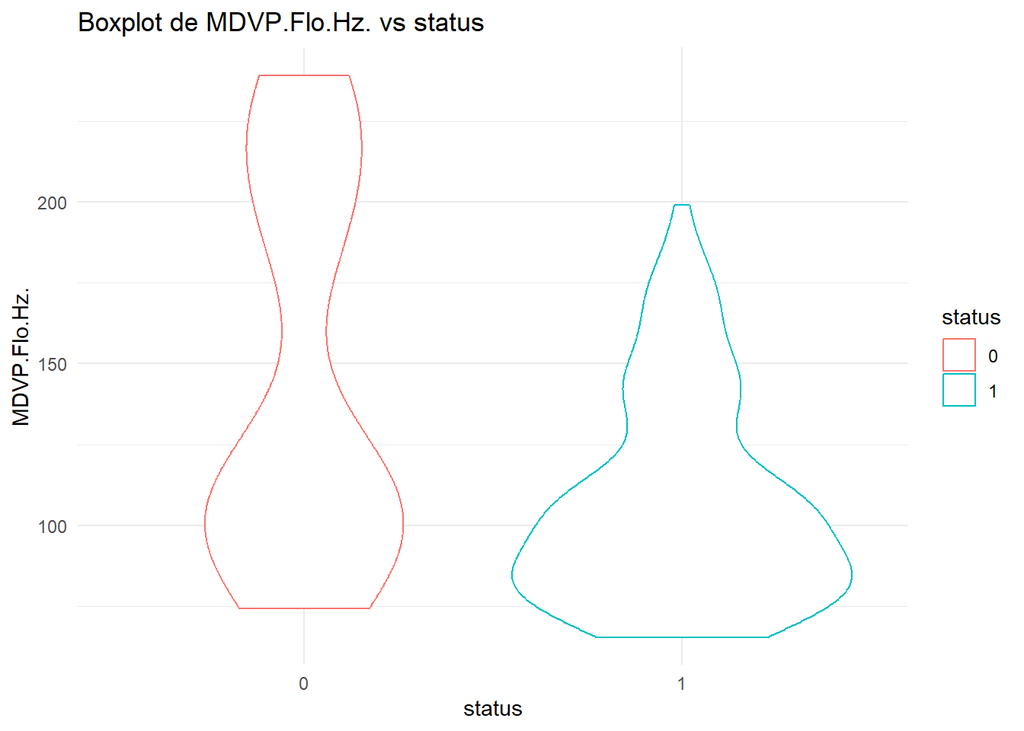

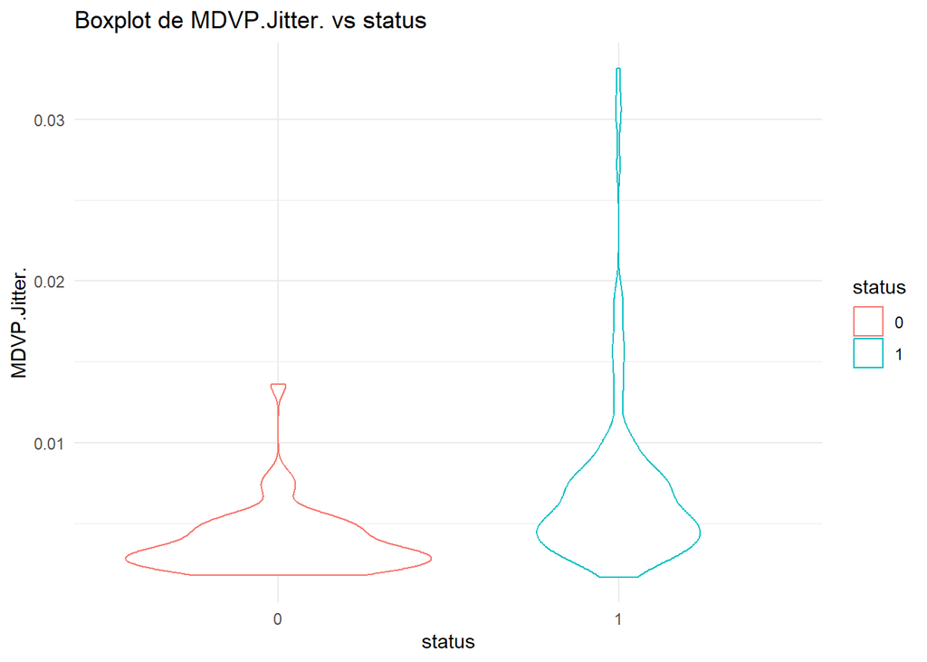

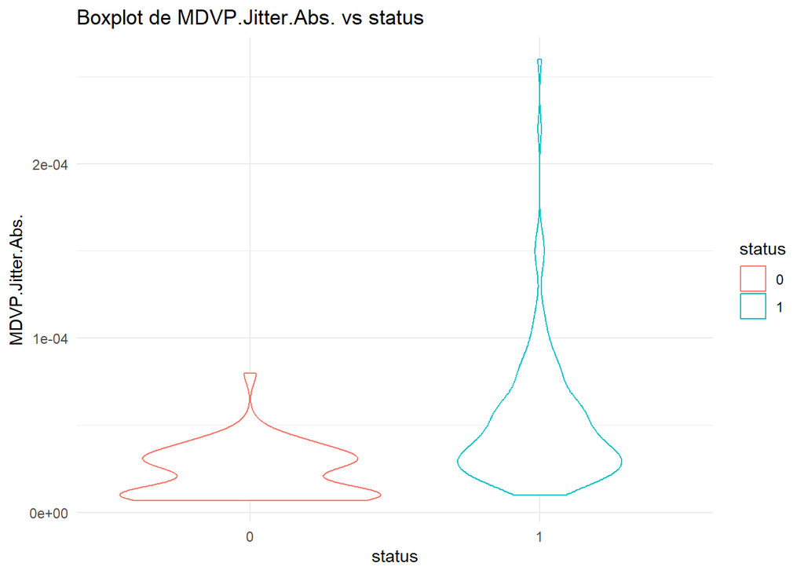

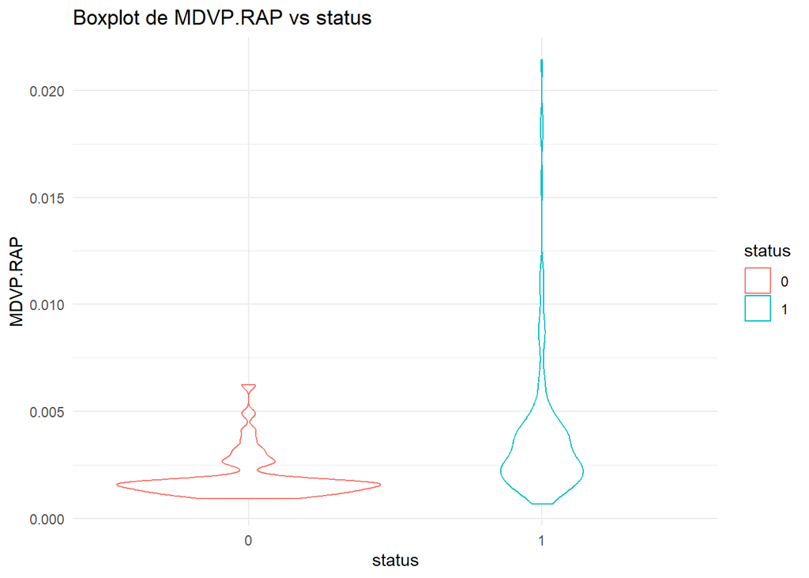

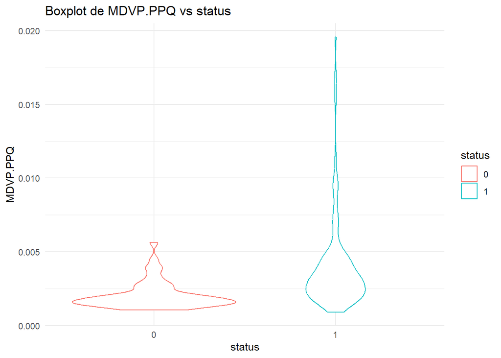

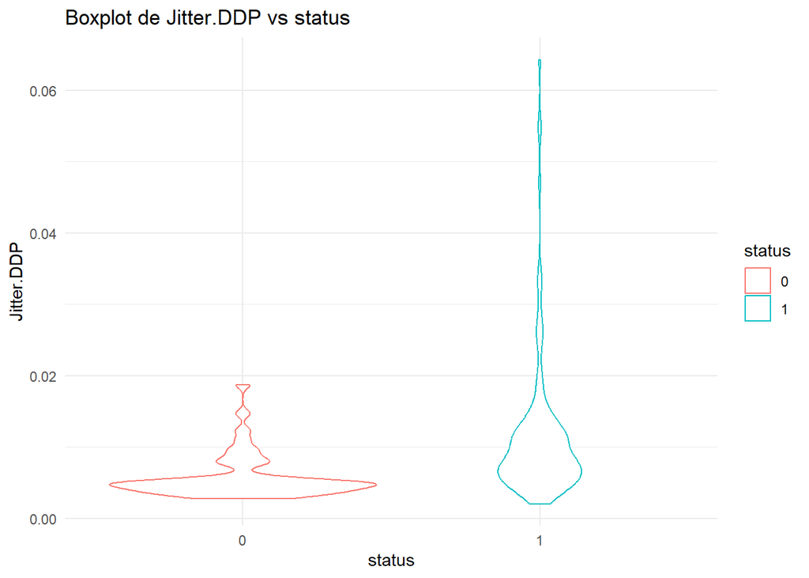

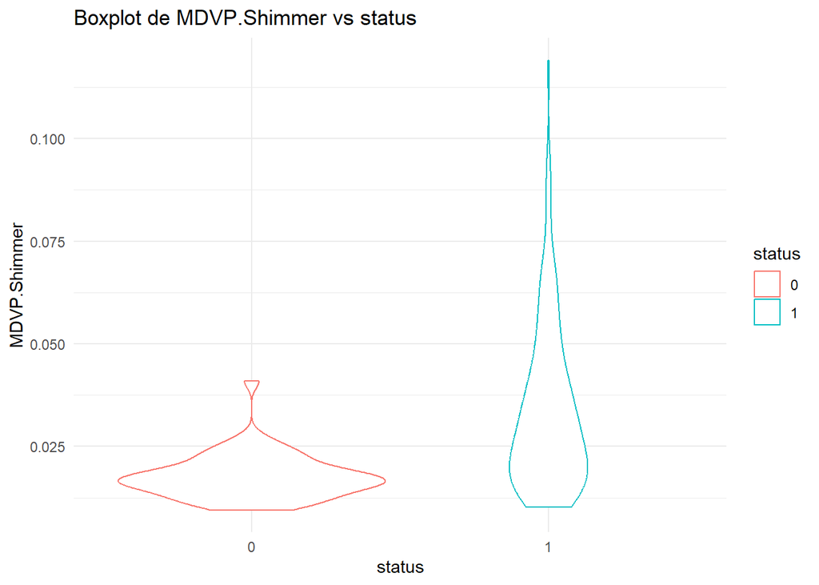

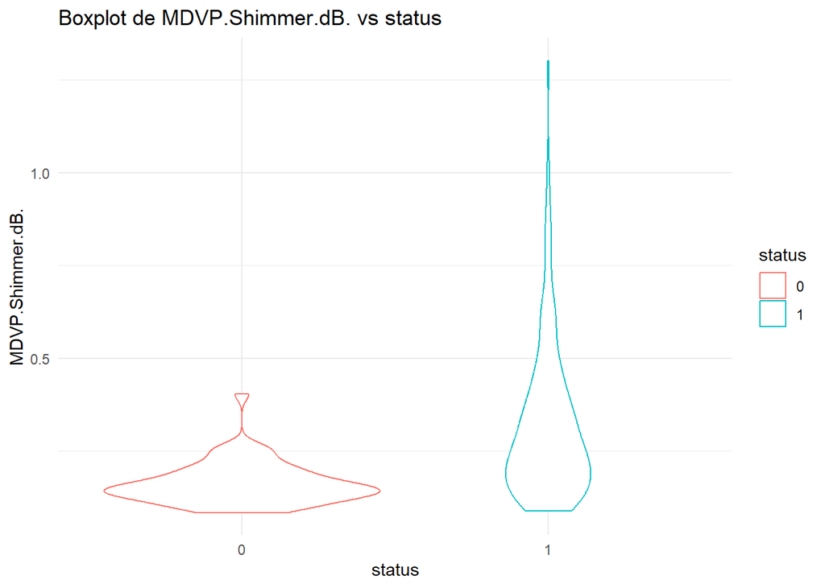

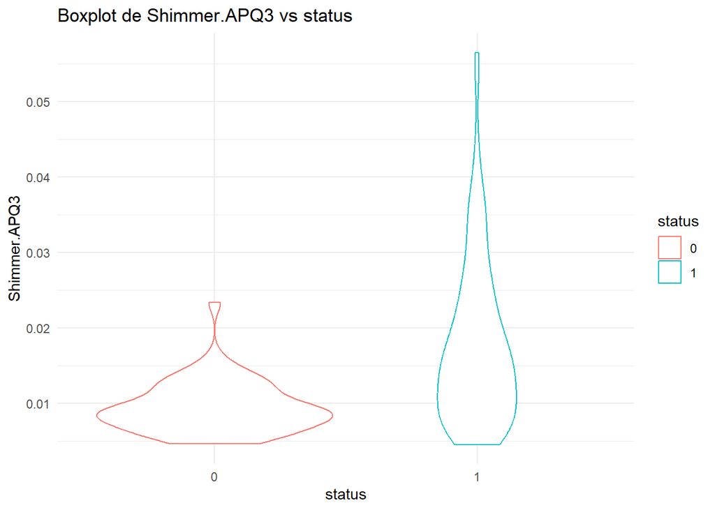

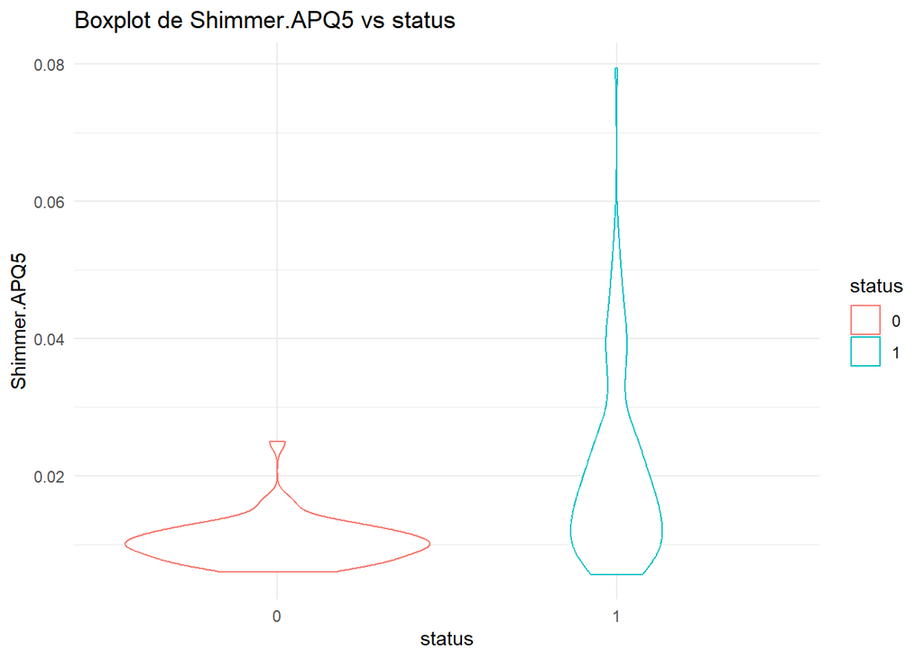

[10 more figures not shown]

```r
# Cogemos las variables numericas
variables_numericas = data %>%
  select(where(is.numeric))

# Hacemos un Violin plot sencillo
for (var in colnames(variables_numericas)) {
  g = ggplot(data, aes(x = status, y = variables_numericas[[var]], col = status)) +
    geom_violin() +
    theme_minimal() +
    labs(x = "status", y = var) +
    ggtitle(paste("Boxplot de", var, "vs status"))

  print(g)

}
```

PODEMOS OBSERVAR, A DIFERENCIA DE LOS BOXPLOTS QUE SON RECTÁNGULOS, UNOS GRÁFICOS QUE NOS PERMITEN VER COMO A DIFERENTES VALORES DE NUESTRAS VARIABLES NUMERICAS, LA DENSIDAD DE PACIENTES QUE HAY.